# Build your own concordance

In the lecture, we discussed how it took 500 Dominican munks to write the first concordance of the Latin bible, and how it took Rabbi Mordecai Nathan 10 years to write the first concordance of the Hebrew bible. With Python, it only takes a matter of seconds to find words in a text, along with the surrounding words.

In this exercise, first run the code and check that everything works. Then, try modifying the code. Do at least to the part where it says **Stop now if you want!** Do as much or as little of the other exercises as you can / want to.

Run each cell in this notebook at a time, in order. If something in one cell doesn't work right, it might be because you have overwritten a variable, so try going back and running all the previous cells again.

The point of the exercise isn't for you to understand all the commands fully; the idea is to start getting you familiar with how jupyter notebooks work, with the concept of copying and modifying code, and hopefully give you a little taste of the power of Python.

```python
# install the natural language toolkit package (nltk), which has a copy of several texts, including the King James Bible
%pip install nltk
```

```python
# import the nltk package so that it is accessible to Python, and download a collection of texts from Project Gutenberg
import nltk
nltk.download('gutenberg')
```

```
True
```

```python
# Create a variable called "bible" which contains the text of the King James bible.
bible = nltk.corpus.gutenberg.raw('bible-kjv.txt')

# make all characters lowercase
bible = bible.lower()

# remove the "\n" characters, which indicate line breaks in the text (newlines)
bible = bible.replace('\n', ' ')

# split up the text into a long list of individual words
bible = bible.split(' ')
```

```python
# make a variable called "concordance", and fill it with every occurrence of the phrase "this world", and a few words preceeding and following "this world"
concordance = []
for i, val in enumerate(bible):
    if val == "world":
        if bible[i-1] == "this":
            concordance.append(str(' '.join(bible[i-5:i+5])))
```

```python
# take a look at what the algorithm has found
concordance
```

```
['for the children of this world are in their generation',
 'them, the children of this world marry, and are given',
 'hateth his life in this world shall keep it unto',
 'shall the prince of this world be cast out. ',
 'should depart out of this world unto the father, having',
 'for the prince of this world cometh, and hath nothing',
 'because the prince of this world is judged.  16:12',
 'of the princes of this world knew: for had they',
 'for the wisdom of this world is foolishness with god.',
 'for the fashion of this world passeth away.  7:32',
 'whom the god of this world hath blinded the minds',
 'chosen the poor of this world rich in faith, and',
 'saying, the kingdoms of this world are become the kingdoms']
```

Let's try again, but this time let's just search for "world" by itself, not "this world".

```python
concordance = []
for i, val in enumerate(bible):
    if val == "world":
        concordance.append(str(' '.join(bible[i-5:i+5])))
```

```python
# take a look at what the algorithm has found
concordance
```

```
['and he hath set the world upon them.  2:9',
 'appeared, the foundations of the world were discovered, at the',
 'him, all the earth: the world also shall be stable,',
 'upon the face of the world in the earth. ',
 'and he shall judge the world in righteousness, he shall',
 'and the foundations of the world were discovered at thy',
 'all the ends of the world shall remember and turn',
 'all the inhabitants of the world stand in awe of',
 'not tell thee: for the world is mine, and the',
 'is thine: as for the world and the fulness thereof,',
 'he hath girded himself: the world also is stablished, that',
 'that the lord reigneth: the world also shall be established',
 'earth: he shall judge the world with righteousness, and the',
 'also he hath set the world in their heart, so',
 'and i will punish the world for their evil, and',
 'kingdoms; 14:17 that made the world as a wilderness, and',
 'fill the face of the world with cities.  14:22',
 'all the kingdoms of the world upon the face of',
 'mourneth and fadeth away, the world languisheth and fadeth away,',
 'earth, the inhabitants of the world will learn righteousness. ',
 'have the inhabitants of the world fallen.  26:19 thy',
 'fill the face of the world with fruit.  27:7',
 'not be ashamed nor confounded world without end.  45:18',
 'since the beginning of the world men have not heard,',
 'power, he hath established the world by his wisdom, and',
 'power, he hath established the world by his wisdom, and',
 'this world, neither in the world to come.  12:33',
 ' 18:7 woe unto the world because of offences! for',
 'be preached in all the world for a witness unto',
 'since the beginning of the world to this time, no,',
 'with persecutions; and in the world to come eternal life.',
 'which have been since the world began: 1:71 that we',
 'caesar augustus that all the world should be taxed. ',
 'all the kingdoms of the world in a moment of',
 'do the nations of the world seek after: and your',
 'for the children of this world are in their generation',
 'present time, and in the world to come life everlasting.',
 'them, the children of this world marry, and are given',
 'in the world, and the world was made by him,',
 'made by him, and the world knew him not. ',
```

[output cut: 58 more lines]

```
 'chosen the poor of this world rich in faith, and',
 'tongue is a fire, a world of iniquity: so is',
 'that the friendship of the world is enmity with god?',
 'be a friend of the world is the enemy of',
 'corruption that is in the world through lust.  1:5',
 'in the flood upon the world of the ungodly; 2:6',
 'escaped the pollutions of the world through the knowledge of',
 'the water: 3:6 whereby the world that then was, being',
 'world.  2:17 and the world passeth away, and the',
 'sons of god: therefore the world knoweth us not, because',
 'not, my brethren, if the world hate you.  3:14',
 'of the world, and the world heareth them.  4:6',
 'of god, and the whole world lieth in wickedness. ',
 'saying, the kingdoms of this world are become the kingdoms',
 'was healed: and all the world wondered after the beast.']
```

Now, in the cell below, modify the code to search for a different word.

```python
# add your modified code here and run the cell...
```

The nltk package has the full text of several other classic books. You can see what they are called by running the command in the cell below:

```python
nltk.corpus.gutenberg.fileids()
```

```
['austen-emma.txt',
 'austen-persuasion.txt',
 'austen-sense.txt',
 'bible-kjv.txt',
 'blake-poems.txt',
 'bryant-stories.txt',
 'burgess-busterbrown.txt',
 'carroll-alice.txt',
 'chesterton-ball.txt',
 'chesterton-brown.txt',
 'chesterton-thursday.txt',
 'edgeworth-parents.txt',
 'melville-moby_dick.txt',
 'milton-paradise.txt',
 'shakespeare-caesar.txt',
 'shakespeare-hamlet.txt',
 'shakespeare-macbeth.txt',
 'whitman-leaves.txt']
```

## Stop now if you want!

If you have come this far, and got everything to work, you can stop if you want! The goal of this assignment is to successfully run and modify some Python code to achieve a goal. But..... if you want to challenge yourself, here are a few more things you can try. In each case, I have given you a little bit of starter code to get you going.

## Challenge 1: build your own concordance

Pick a different book and a different word, or pair of words. Copy and paste from the code above to write some Python code that searches the book of your choice for the word or pair of words of your choice. Put this code in the cell below. By the way, some of the texts use the characters "\r" for "carriage return" instead of "\n" for "newline". You can remove these the same way that you remove the "\n" characters.

```python
# add your code to search for a word or pair of words in a different book here
```

## Challenge 2: compare lengths of books

We can use the command `len` to find how many items there are in a list. E.g., to find the number of words in the list called `bible`, above, we can write: `len(bible)`. Which book in the books included in `nltk` has the most words?

book = nltk.corpus.gutenberg.raw('austen-emma.txt')

```python
# solution 1: print all the titles and numbers of words
books = nltk.corpus.gutenberg.fileids()

for title in books:
    book = nltk.corpus.gutenberg.raw(title)
    book = book.replace('\n', ' ')
    book = book.split(' ')
    print(title, len(book))
```

```
austen-emma.txt 164457
austen-persuasion.txt 86270
austen-sense.txt 123514
bible-kjv.txt 848001
blake-poems.txt 8886
bryant-stories.txt 49404
burgess-busterbrown.txt 16305
carroll-alice.txt 28387
chesterton-ball.txt 86481
chesterton-brown.txt 80382
chesterton-thursday.txt 59297
edgeworth-parents.txt 177685
melville-moby_dick.txt 221023
milton-paradise.txt 91832
shakespeare-caesar.txt 23339
shakespeare-hamlet.txt 33477
shakespeare-macbeth.txt 20164
whitman-leaves.txt 138730
```

```python
# solution 2: make a list of titles and a list of wordcounts, zip them together, then sort them based on wordcount

books = nltk.corpus.gutenberg.fileids()

titles = []
numwords = []
for title in books:
    book = nltk.corpus.gutenberg.raw(title)
    book = book.replace('\n', ' ')
    book = book.split(' ')
    titles.append(title[0:-4])
    numwords.append(len(book))

booklengths = list(zip(titles, numwords))
booklengths_sorted = sorted(booklengths, key = lambda x: x[1])
booklengths_sorted
```

```
[('blake-poems', 8886),
 ('burgess-busterbrown', 16305),
 ('shakespeare-macbeth', 20164),
 ('shakespeare-caesar', 23339),
 ('carroll-alice', 28387),
 ('shakespeare-hamlet', 33477),
 ('bryant-stories', 49404),
 ('chesterton-thursday', 59297),
 ('chesterton-brown', 80382),
 ('austen-persuasion', 86270),
 ('chesterton-ball', 86481),
 ('milton-paradise', 91832),
 ('austen-sense', 123514),
 ('whitman-leaves', 138730),
 ('austen-emma', 164457),
 ('edgeworth-parents', 177685),
 ('melville-moby_dick', 221023),
 ('bible-kjv', 848001)]
```

## Challenge 3: what are the most frequent words?

`nltk` has a built-in function called `FreqDist` which counts up how many times each word in a text occurs. So, if you have a list called `words` which contains all the words in a book, you can find the frequencies of all of them by writing `freq = nltk.FreqDist(words)`. You can then get the e.g. ten most common words by writing `freq.most_common(10)`. What are the ten most common words in Jane Austen's "Emma"? What about Herman Melville's "Moby Dick"?

```python
# possible solution

book = nltk.corpus.gutenberg.raw('austen-emma.txt')
words = book.lower()
words = words.replace('\n', ' ')
words = words.split(' ')
freq = nltk.FreqDist(words)


print("Austen: ", freq.most_common(10))

print(" ")

book = nltk.corpus.gutenberg.raw('melville-moby_dick.txt')
words = book.lower()
words = words.replace('\n', ' ')
words = words.split(' ')
freq = nltk.FreqDist(words)

print("Melville: ", freq.most_common(10))
```

```
Austen:  [('', 6290), ('the', 5120), ('to', 5079), ('and', 4445), ('of', 4196), ('a', 3055), ('i', 2602), ('was', 2302), ('she', 2169), ('in', 2091)]

Melville:  [('the', 12757), ('of', 6014), ('', 5720), ('and', 5629), ('to', 4192), ('a', 4095), ('in', 3756), ('\r', 3273), ('that', 2537), ('his', 2214)]
```

## Challenge 4: Remove stopwords

Often, the most frequent words are not the most interesting ones. Words like "a" and "the" are so common in English, that they don't really tell us much about the text. That is why we often remove "stopwords", that is, a list of the most common words in English, before e.g. counting frequencies. Below is some starter code to remove stopwords. Use these snippets to see what the most common words in Emma and Moby Dick are after removing these most common words.

Hint: In Moby Dick, you will also have to remove the string `\r`, in addition to removing `\n`.

```python
# list of stopwords
stopwords = ["", "i", "me", "my", "myself", "we", "our", "ours", "ourselves", "you", "your", "yours", "yourself", "yourselves", "he", "him", "his", "himself", "she", "her", "hers", "herself", "it", "its", "itself", "they", "them", "their", "theirs", "themselves", "what", "which", "who", "whom", "this", "that", "these", "those", "am", "is", "are", "was", "were", "be", "been", "being", "have", "has", "had", "having", "do", "does", "did", "doing", "a", "an", "the", "and", "but", "if", "or", "because", "as", "until", "while", "of", "at", "by", "for", "with", "about", "against", "between", "into", "through", "during", "before", "after", "above", "below", "to", "from", "up", "down", "in", "out", "on", "off", "over", "under", "again", "further", "then", "once", "here", "there", "when", "where", "why", "how", "all", "any", "both", "each", "few", "more", "most", "other", "some", "such", "no", "nor", "not", "only", "own", "same", "so", "than", "too", "very", "s", "t", "can", "will", "just", "don", "should", "now"]
```

```python
# code to remove stopwords.
words = [word for word in words if word not in stopwords]
```

```python
# possible solution

book = nltk.corpus.gutenberg.raw('austen-emma.txt')
words = book.lower()
words = words.replace('\n', ' ')
words = words.split(' ')
words = [word for word in words if word not in stopwords]
freq = nltk.FreqDist(words)


print("Austen: ", freq.most_common(10))

print(" ")

book = nltk.corpus.gutenberg.raw('melville-moby_dick.txt')
words = book.lower()
words = words.replace('\n', ' ')
words = words.replace('\r', ' ')
words = words.split(' ')
words = [word for word in words if word not in stopwords]
freq = nltk.FreqDist(words)

print("Melville: ", freq.most_common(10))
```

```
Austen:  [('mr.', 1097), ('could', 800), ('would', 795), ('mrs.', 675), ('miss', 568), ('must', 543), ('emma', 481), ('much', 427), ('every', 425), ('said', 392)]

Melville:  [('one', 779), ('like', 564), ('upon', 556), ('whale', 528), ('old', 425), ('would', 416), ('though', 311), ('great', 292), ('still', 282), ('seemed', 273)]
```

```
Emma
```

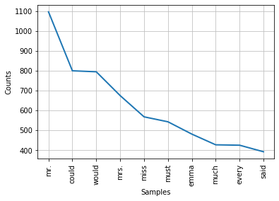

```
Moby Dick
```

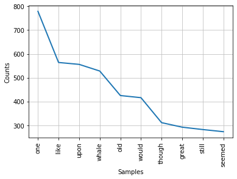

```python
book = nltk.corpus.gutenberg.raw('austen-emma.txt')
words = book.lower()
words = words.replace('\n', ' ')
words = words.split(' ')
words = [word for word in words if word not in stopwords]
freq = nltk.FreqDist(words)

print('Emma')
freq.plot(10)

print(" ")

print('Moby Dick')
book = nltk.corpus.gutenberg.raw('melville-moby_dick.txt')
words = book.lower()
words = words.replace('\n', ' ')
words = words.replace('\r', ' ')
words = words.split(' ')
words = [word for word in words if word not in stopwords]
freq = nltk.FreqDist(words)

freq.plot(10)
```